# Laboratorio 2: Hiperplano de máxima separación - Caso no separable (Soft-margin SVM)

Optimización Convexa en Aprendizaje Automático

Autor/a

Víctor Aceña Gil - Antonio Alonso Ayuso

Fecha de publicación

4 de agosto de 2026

Supongamos ahora que tenemos dos clases con solapamiento e intentamos resolver el problema como en el caso anterior.

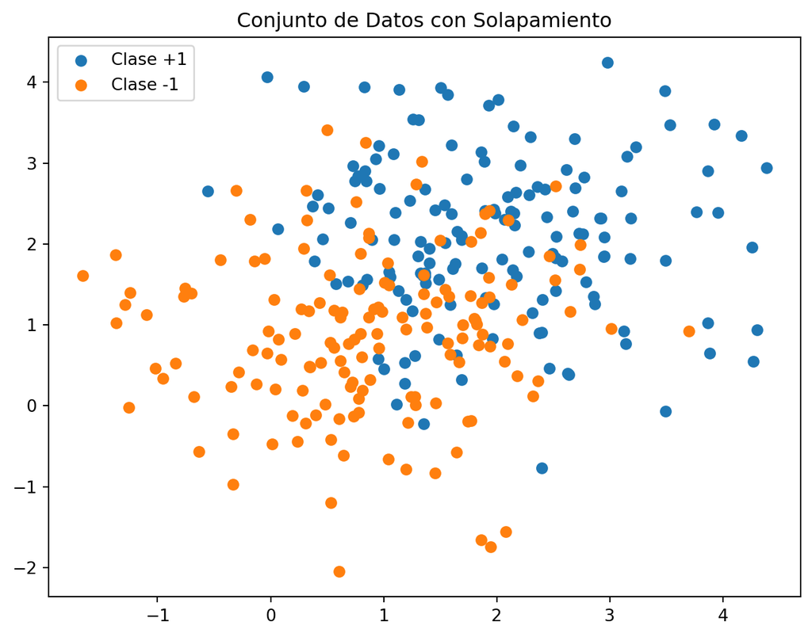

```python
import numpy as np
import matplotlib.pyplot as plt

np.random.seed(0)

# Generamos dos nubes normales con cierto solapamiento
# Clase +1
x_pos = np.random.randn(150, 2) + np.array([2, 2])  # Desplazamos esta nube a una media diferente

# Clase -1
x_neg = np.random.randn(150, 2) + np.array([1, 1])  # Desplazamos esta nube a otra media

# Combinamos los datos positivos y negativos
X = np.vstack((x_pos, x_neg))
y = np.hstack((np.ones(150), -1*np.ones(150)))  # Etiquetas +1 para la clase positiva, -1 para la negativa

# Visualización de los datos
plt.figure(figsize=(8, 6))
plt.scatter(X[y == 1, 0], X[y == 1, 1], label='Clase +1')
plt.scatter(X[y == -1, 0], X[y == -1, 1], label='Clase -1')
plt.title('Conjunto de Datos con Solapamiento')
plt.legend()
plt.show()
```

```python
import cvxpy as cp

m, n = X.shape

w = cp.Variable(n)
b = cp.Variable()

# Función objetivo
objective = cp.Minimize(0.5*cp.square(cp.norm(w)) )

# Restricciones
constraints = [cp.multiply(y, X @ w + b) >= 1]

# Resolver el problema
prob = cp.Problem(objective, constraints)
prob.solve()

print("Valor óptimo de w: ", w.value)
print("Valor óptimo de b: ", b.value)
```

```
Valor óptimo de w:  None
Valor óptimo de b:  None
```

# 1 Transición del margen duro al margen suave

En el contexto de un margen duro, como se ha visto en el ejemplo anterior, el modelo intenta encontrar un hiperplano que separe completamente las dos clases sin solapamiento. Sin embargo, este enfoque encuentra un problema fundamental cuando los datos no son linealmente separables.

## 1.1 Hiperplano separador con el margen duro

El hiperplano de margen duro se formula de la siguiente manera:

$$\begin{aligned}
& \underset{\mathbf{w}, b}{\text{minimizar}}
& & \frac{1}{2} ||\mathbf{w}||^2 \\
& \text{sujeto a}
& & y_i(\mathbf{w}^T \mathbf{x}_i + b) \geq 1, \; \forall i
\end{aligned}$$

Esta formulación implica que cada muestra debe estar al menos a una distancia unitaria del hiperplano. En casos donde los datos no son completamente separables, estas restricciones se vuelven inalcanzables, llevando a un problema de optimización sin solución factible.

## 1.2 Introducción del margen suave

Para abordar este problema, se introduce el concepto de margen suave, que permite cierta flexibilidad en la clasificación de las muestras. Esto se logra mediante variables de holgura $\xi_i$ y un parámetro de regularización $C$, reformulando el problema de la siguiente manera:

$$\begin{aligned}
& \underset{\mathbf{w}, b, \boldsymbol{\xi}}{\text{minimizar}}
& & \frac{1}{2}||\mathbf{w}||^2 + C \sum_{i=1}^n \xi_i \\
& \text{sujeto a}
& & y_i(\mathbf{w}^T \mathbf{x_i} + b) \geq 1 - \xi_i, \\
& & & \xi_i \geq 0, \; i = 1, \ldots, n
\end{aligned}$$

Aquí, las variables de holgura $\xi_i$ permiten que algunas muestras estén del lado incorrecto del margen, con $C$ controlando el balance entre la maximización del margen y la penalización por violaciones del margen. Este enfoque es mucho más flexible y práctico para conjuntos de datos reales, donde la separabilidad completa raramente es posible.

A nivel teórico, el problema de margen suave se convierte en un problema de margen duro cuando $C$ tiende al infinito. En la práctica, esto significa elegir un valor de $C$ extremadamente grande. Cuando $C$ es muy grande, el término de penalización por violaciones del margen (las variables de holgura $\xi_i$) en la función objetivo se vuelve tan significativo que el modelo intenta evitar cualquier violación del margen, comportándose así como un problema de margen duro.

## 1.3 Conclusión

El problema relajado de margen suave proporciona una solución viable y eficiente para el problema de clasificación, especialmente en casos de datos no separables, como en el ejemplo previo. Esta adaptabilidad lo hace adecuado para una variedad de aplicaciones prácticas, manejando eficazmente los datos ruidosos o solapados.

## 1.4 Análisis de convexidad

El problema de optimización con margen suave es un problema convexo, y aquí está el porqué:

1. **Función Objetivo**: La función objetivo es $\frac{1}{2}\mathbf{w}^T\mathbf{w} + C \sum_{i=1}^t \xi_i$. Esta función es la suma de una norma cuadrada (que es una función convexa debido a que su segunda derivada es constante y positiva) y un término lineal ponderado por el parámetro de regularización $C$. La suma de funciones convexas es convexa, por lo que la función objetivo es convexa.
2. **Restricciones**:
   - Las restricciones de la forma $y_i(\mathbf{w}^T \mathbf{x}_i + b) \geq 1 - \xi_i$ son lineales en términos de $\mathbf{w}$, $b$ y $\xi_i$, y por lo tanto son convexas. Aunque el término $-\xi_i$ introduce una desviación de la forma lineal original, la restricción en su conjunto sigue siendo lineal y por ende convexa.
   - Las restricciones $\xi_i \geq 0$ son restricciones de no negatividad, que también son convexas.

Dado que la función objetivo y todas las restricciones son convexas, el problema en su conjunto es un problema de optimización convexa. Los problemas de optimización convexa tienen la propiedad ventajosa de que cualquier mínimo local también es un mínimo global, lo que facilita la búsqueda de la solución óptima. En este contexto, la introducción de las variables de holgura $\xi_i$ y el parámetro de regularización $C$ permite el manejo de datos no completamente separables, ofreciendo una solución de margen suave que equilibra entre el margen máximo y la penalización por clasificación incorrecta.

# 2 Ejemplo de resolución

## 2.1 Definir variables de optimización

Definimos las variables de optimización `w` (pesos), `b` (sesgo) y `xi` (variables de holgura) usando `cvxpy`. Estas variables se ajustarán para encontrar el hiperplano de máxima separación en un modelo de margen suave.

- `w`: Vector de pesos, que define la orientación del hiperplano.
- `b`: Término de sesgo, que define la distancia del hiperplano al origen.
- `xi`: Variables de holgura, que permiten cierta flexibilidad en la clasificación para manejar datos no completamente separables.
- `C`: Parámetro de regularización que equilibra la maximización del margen y la minimización de la clasificación incorrecta.

```python
import cvxpy as cp
m, n = X.shape
w = cp.Variable(n)
b = cp.Variable()
xi = cp.Variable(m)
C = 0.01
```

## 2.2 Establecer el objetivo de optimización

El objetivo de la optimización es encontrar un hiperplano que maximice la separación entre las dos clases. Esto se logra minimizando una función objetivo que consta de dos términos:

1. La norma (longitud) del vector de pesos `w`, que favorece un hiperplano con un margen grande.
2. La suma de las variables de holgura `xi`, ponderada por un parámetro de regularización `C`, que permite cierto grado de clasificación incorrecta para manejar datos no completamente separables.

Matemáticamente, el objetivo se representa como:

$$\underset{\mathbf{w}, \boldsymbol{\xi}}{\text{minimizar}} \quad \frac{1}{2} ||\mathbf{w}||_2^2 + C \sum \xi_i$$

**Nota**: La norma 2 de un vector `w`, denotada como $||\mathbf{w}||_2$, se refiere a la norma euclidiana, que es la longitud del vector en el espacio euclidiano. Se calcula como la raíz cuadrada de la suma de los cuadrados de sus componentes, es decir, $||\mathbf{w}||_2 = \sqrt{w_1^2 + w_2^2 + \ldots + w_n^2}$.

```python
import cvxpy as cp
objective = cp.Minimize(0.5 * cp.square(cp.norm(w)) + C * cp.sum(xi))
```

## 2.3 Definir las restricciones

Las restricciones en un problema de margen suave garantizan que todas las muestras de cada clase estén en el lado correcto del hiperplano, permitiendo cierto grado de flexibilidad para manejar datos no completamente separables. Para cada punto de datos $\mathbf{x}_i$ con etiqueta $y_i$, la restricción se define como:

$$y_i (\mathbf{w}^T \mathbf{x}_i + b) \geq 1 - \xi_i, \quad \text{para todo } i$$

$$\xi_i \geq 0, \quad \text{para todo } i$$

```python
import cvxpy as cp
constraints = [cp.multiply(y, X @ w + b) >= 1 - xi, xi >= 0]
```

# 3 Resolver el problema de optimización

Una vez definidas las variables (`w`, `b` y `xi`), el objetivo y las restricciones, el siguiente paso es crear y resolver el problema de optimización. Esto se realiza mediante CVXPY, una biblioteca de Python diseñada para resolver problemas de optimización convexa.

Al resolver este problema, CVXPY automáticamente encuentra la solución que minimiza nuestro objetivo y satisface las restricciones. El proceso de optimización nos proporcionará los valores óptimos de `w` (el vector de pesos) y `b` (el término de sesgo), que definen el hiperplano de máxima separación.

```python
import cvxpy as cp
prob = cp.Problem(objective, constraints)
prob.solve()

print("Valor óptimo de w: ", w.value)
print("Valor óptimo de b: ", b.value)
```

```
Valor óptimo de w:  [0.46717737 0.53780516]
Valor óptimo de b:  -1.4199474054594623
```

## 3.1 Visualizar el hiperplano resultante

La ecuación del hiperplano se deriva de la formulación general y se adapta para su visualización en un gráfico bidimensional. A continuación se explica cómo se obtiene esa ecuación:

En este problema, el hiperplano que separa dos clases se define por la ecuación:

$$\mathbf{w}^T \mathbf{x} + b = 0$$

donde:

- $\mathbf{w} = [w_0, w_1]$ es el vector de pesos.
- $\mathbf{x} = [x_1, x_2]$ representa un punto en el espacio de características.
- $b$ es el término de sesgo.

Para visualizar este hiperplano en un espacio bidimensional (por ejemplo, en un gráfico con ejes x e y), reorganizamos la ecuación para despejar una de las variables, generalmente $x_2$ (que podemos considerar como $y$ en el gráfico de dispersión), en función de la otra ($x_1$, que consideramos como $x$ en el gráfico). La ecuación reorganizada nos permite trazar una línea en el gráfico que representa el hiperplano.

Reorganizando la ecuación del hiperplano:

$$\mathbf{w}^T \mathbf{x} + b = w_0 x_1 + w_1 x_2 + b = 0$$

Despejando $x_2$ (o $y$):

$$w_1 x_2 = -w_0 x_1 - b$$

$$x_2 = -\frac{w_0}{w_1} x_1 - \frac{b}{w_1}$$

Por lo tanto, en términos de un gráfico de dispersión con $x$ e $y$:

$$y = -\frac{w_0}{w_1} x - \frac{b}{w_1}$$

Esta es la ecuación que usarías para trazar el hiperplano en un gráfico de dispersión, utilizando los valores óptimos de $w_0$, $w_1$ y $b$ obtenidos de la solución de tu problema de optimización.

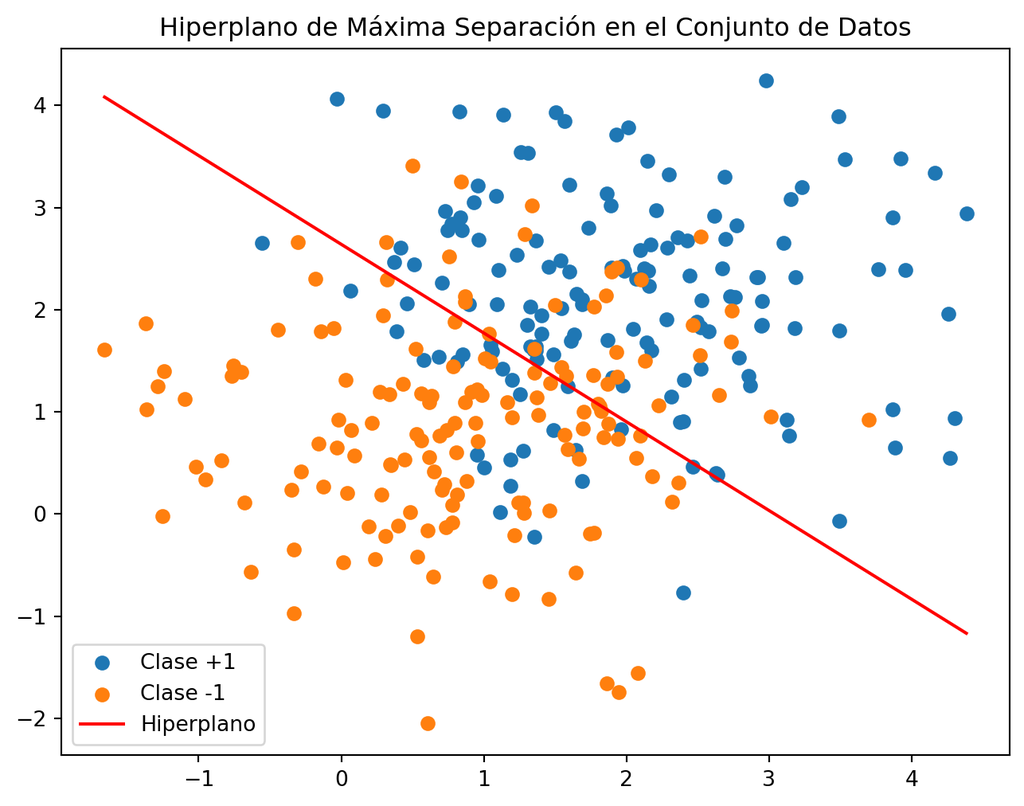

```python
# Obtener valores de w y b
w_opt = w.value
b_opt = b.value

# Encontrar los límites para el eje x basándose en los datos
x_min, x_max = X[:, 0].min(), X[:, 0].max()

# Crear una línea para el hiperplano
x_values = np.linspace(x_min, x_max, 100)
y_values = -(w_opt[0] * x_values + b_opt) / w_opt[1]

# Visualizar hiperplano y datos
plt.figure(figsize=(8, 6))
plt.scatter(x_pos[:, 0], x_pos[:, 1], label='Clase +1')
plt.scatter(x_neg[:, 0], x_neg[:, 1], label='Clase -1')
plt.plot(x_values, y_values, label='Hiperplano', color='red')
plt.title('Hiperplano de Máxima Separación en el Conjunto de Datos')
plt.legend()
plt.show()
```

# 4 Evaluar la calidad del modelo

Para evaluar la calidad del modelo, calculamos la exactitud (*accuracy*), que mide el porcentaje de predicciones correctas realizadas por el modelo en comparación con las etiquetas reales. Este es un paso crucial para entender el rendimiento del modelo en los datos proporcionados.

El proceso es el siguiente:

1. Calcular las predicciones del modelo. Para cada punto de datos en `X`, multiplicamos por `w_opt`, añadimos `b_opt` y aplicamos la función signo (`np.sign`). Esto nos da una predicción de +1 o -1 para cada muestra.
2. Comparar estas predicciones con las etiquetas reales `y` y calcular la exactitud como la media de las predicciones correctas.

```python
# Calcular las predicciones
predicciones = np.sign(X @ w_opt + b_opt)  # Esto dará +1 o -1 como predicciones

# Calcular la exactitud
accuracy = np.mean(predicciones == y)  # Compara las predicciones con las etiquetas reales

print("Accuracy del modelo:", accuracy)
```

```
Accuracy del modelo: 0.8
```

# 5 Efecto del parámetro C

```python
# Establecer la semilla para la reproducibilidad
np.random.seed(0)

# Parámetro para el número de datos por clase
num_datos_por_clase = 30  # Puedes cambiar este número según sea necesario

# Generar datos para dos clases con poco solape
x_pos = np.random.randn(num_datos_por_clase, 2) + np.array([2, 2])
x_neg = np.random.randn(num_datos_por_clase, 2) + np.array([1, 1.5])

X = np.vstack((x_pos, x_neg))
y = np.hstack((np.ones(num_datos_por_clase), -1 * np.ones(num_datos_por_clase)))
```

# 6 Visualización del efecto del parámetro de regularización $C$

Para observar cómo diferentes valores del parámetro de regularización $C$ afectan la decisión de clasificación, visualizaremos los hiperplanos resultantes para varios valores de $C$. Esto nos ayudará a entender la relación entre $C$ y la flexibilidad del modelo en cuanto a la clasificación y el margen.

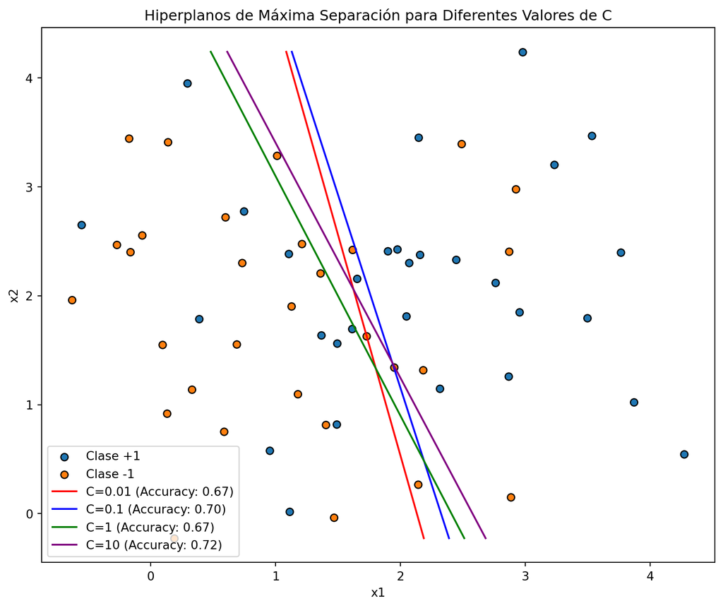

```python
import cvxpy as cp
# Valores de C para probar
valores_C = [0.01, 0.1, 1, 10]
colores = ['red', 'blue', 'green', 'purple']

# Encontrar los límites para el eje y basándose en los datos
y_min, y_max = X[:, 1].min(), X[:, 1].max()

# Crear una figura para la visualización
plt.figure(figsize=(10, 8))

# Graficar los puntos de datos
plt.scatter(x_pos[:, 0], x_pos[:, 1], label='Clase +1', edgecolor='k')
plt.scatter(x_neg[:, 0], x_neg[:, 1], label='Clase -1', edgecolor='k')

# Resolver el problema de optimización para cada valor de C y graficar el hiperplano correspondiente
for idx, C in enumerate(valores_C):
    # Definir las variables de optimización
    w = cp.Variable(2)
    b = cp.Variable()
    xi = cp.Variable(len(X))

    # Función objetivo
    objective = cp.Minimize(0.5 * cp.square(cp.norm(w)) + C * cp.sum(xi))

    # Restricciones
    constraints = [cp.multiply(y, X @ w + b) >= 1 - xi, xi >= 0]

    # Resolver el problema
    prob = cp.Problem(objective, constraints)
    prob.solve()

    # Obtener valores de w y b
    w_opt = w.value
    b_opt = b.value

    # Calcular las predicciones y la exactitud
    predicciones = np.sign(X @ w_opt + b_opt)
    accuracy = np.mean(predicciones == y)

    # Ajustar los valores de x para cubrir los límites verticales
    y_values = np.linspace(y_min, y_max, 100)
    x_values = -(y_values * w_opt[1] + b_opt) / w_opt[0]

    # Graficar el hiperplano
    plt.plot(x_values, y_values, label=f'C={C} (Accuracy: {accuracy:.2f})', color=colores[idx])

# Configurar leyendas y títulos
plt.title('Hiperplanos de Máxima Separación para Diferentes Valores de C')
plt.xlabel('x1')
plt.ylabel('x2')
plt.legend()
plt.show()
```

## 6.1 ¿Qué hace $C$?

- **Margen versus Error de Clasificación**: Un valor bajo de $C$ pone menos énfasis en clasificar todas las muestras correctamente y más en maximizar el margen. Esto puede permitir ciertos errores de clasificación pero resulta en un modelo más generalizado. Por el contrario, un valor alto de $C$ busca reducir los errores de clasificación, incluso a expensas de un margen más estrecho.
- **Prevención del Sobreajuste**: Al ajustar $C$, controlamos el *trade-off* entre un modelo que se ajusta demasiado a los datos de entrenamiento (sobreajuste) y uno que no capta suficientemente las características de los datos (subajuste).